# SMT40-Prospectus

David John Baker

October 26th, 2018

## Motivation

Melodic dictation is the process in which an individual hears a melody, retains it in memory, then uses their knowledge of Western musical notation to recreate the mental image of the melody on paper in a limited time frame. For many, becoming proficient at this task is at the core of developing one’s aural skills which is evident from the fact that most aural skills textbooks with content devoted to honing one’s listening abilities have sections devoted to learning how to take melodic dictation (Karpinski 2000). Additionally, any school accredited by the National Association of Schools of Music in North America requires students to learn this skill (“National Association of Schools of Music Handbook” 2018, sec. VIII.6.B.2.A). Yet despite this ubiquity in the pedagogy of melodic dictation, exactly *how* this process works is not understood: Music theorists do not have an explanatory theory of melodic dictation.

The lack of knowledge regarding melodic dictation is alarming given the degree music theorists are engaged with the teaching and assessing of this ability. As a community, a more systematic understanding of *how* people learn melodies is not only important from an pedagogical point of view, but understanding how people learn and perceive melodies is at the locus of research tangential to music theory, music education, as well as music cognition. While there have been repeated calls throughout the past few decades to synthesize these disparate literatures (Butler 1997; Karpinski 2000; Klonoski 2000), the literature is sparse in relation to how frequent melodic dictation appears as part of our curricula[^1]. Reviewing the current state of research on melodic dictation highlights the need for the music theory community to better understand melodic dictation and the literature that surrounds it.

1. Hearing
2. Short Term Melodic Memory
3. Musical Understanding
4. Notation

and are conceptualized as a looping process that is done over each chunk of musical material that the listener focuses on via a process of extractive listening. His flowchart of the process is reproduced below in Figure 1.

[figure not shown]

Karpinski Idealized flowchart for melodic dictation

As a pedagogical tool, Karpinski’s model distills a complicated and almost esoteric process into a manageable system that benefits both students as well as aural skills pedagogues. Karpinski’s model describes the process of melodic dictation but his model makes no claims as to *how* the process happens. Though not the original intention of the model, this four step model lacks robustness in that it is agnostic to both differences at the individual level, as well as the for differences in melodic material.

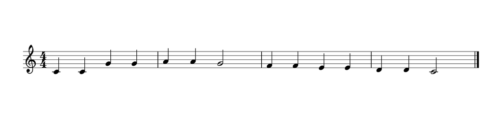

Melodies of Equal Length

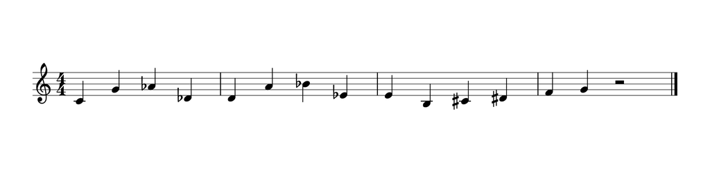

Melodies of Equal Length

In this dissertation, I continue the line of research began with Gary Karpinski’s four step model of melodic dictation by stepping beyond this four step model. I do this by first exploring how both individual experiences and musical material can affect melodic dictation separately, examine how these factors interact, then finally posit an explanatory computational model of melodic dictation. The past 20 years of research since *Aural Skills Acquisition* have highlighted the importance of taking into account both ability to understand how individual differences play a role in music perception tasks as well as an ability to quantify and operationalize differences in melodies that reflect a theorists’ intuitive understanding of melodic material. In order to organize and then reflect on the vast amount of factors that could contribute to how a person performs in melodic dictation I propose a taxonomy of parameters with both individual (e.g. cognitive and environmental) and musical (e.g. structural and experimental) parameters from the last twenty years that should be further explored when looking at melodic dictation in order to have a more complete understanding of how melodic dictation works.

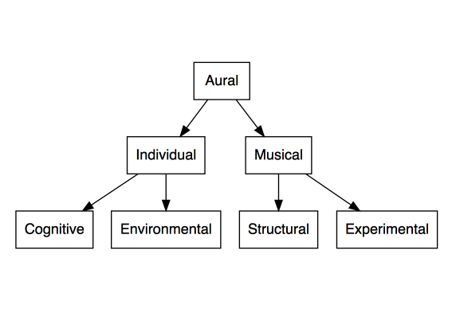

Taxonomy of Factors Relating to Melodic Dictation

Using this taxonomy as a guide, I investigate factors thought to contribute to tasks of melodic dictation using diverse methodological toolbox which borrows techniques ranging from cognitive psychology, to computational musicology, and music theory.

## Present Research Question

This dissertation takes an interdisciplinary approach to answer the question: *how* does melodic dictation work? In order to answer this question comprehensively I synthesize and utilize work from music theory, music education, and music cognition to answer questions related to this. Specifically, I set out to answer

1. To what degree are individual differences in cognitive ability predictive of a person’s ability to perform musical memory tasks?
2. To what degree do abstracted melodic features help determine the difficulty of dictation melody in line with expert intuition?
3. How can patterns from a corpus of sight singing melodies serve as representations of what people implicitly and explicitly know?
4. If cast as an experiment, how can we predict how well someone does on a melodic dictation task when both individual and musical features are combined? What problems arise for this kind of research to be pursued?
5. Is it possible to posit a computational, explanatory model of melodic dictation that explains *how* the process works that mirrors the phenomenological decision process that individuals engage with when performing melodic dictation?

With each of these five questions serving as the basis for each of the five chapters of original content, I next detail what I will use for each of these methodologies in detail.

## Outline Research Methods

In order to investigate my first research question, I analyze and interpret data from a large scale experiment conducted over the last year in collaboration with the Louisiana State University’s cognitive psychology program. The experiment uses a large sample of (N = 346) students who took part in a multi part experiment where we took measures of cognitive ability using multiple measures of for both general fluid intelligence and working memory capacity, measures of musical background via subjective self report, and then also an objective test of musical memory via a melodic memory test. Given the complexity of variables at play, I analyze the data using structural equation modeling– a statistical technique developed in order to parse out causal relationships within covariance structures– and find evidence for that working memory plays a large role in tasks of musical perception. These results corroborate earlier theoretical claims regarding the need to investigate musical working memory (Berz, 1995).

I then introduce a novel corpus in the third chapter that will consist of over 600 sight singing melodies. Using recent advancements in computational musicology, I show how there are statistical norms present in this corpus and and suggest that there is a link between using these melodies as an individual’s implicit knowledge of a musical structure. In the fourth chapter I demonstrate how computationally extracted features can serve as a quantifiable proxy for a pedagogues’ intuition and propose application for future research. Following earlier claims by Meyer (1956) and later computationally driven research by Pearce (2018) I note how information derived from these corpus studies can be incorporated in experiments investigating melodic dictation. The corpus here also can be then utilized by other researchers who wish to investigate corpus level claims.

Synthesizing the assumptions and findings from the previous three chapters, I combine the work on individual differences and melodic differences in order to operationalize all aspects here and put them together in an experiment. Here I reflect on the many choices that can be made in at this process and talk about implications and limitations of measuring melodic dictation in an experimental setting. Using these experimental methods allows the researcher to determine what happens when the aforementioned musical materials are manipulated in an ecologically valid setting. Findings from this chapter corroborate earlier findings that musical features do in fact play a large role in an individual’s ability to perform melodic dictation. In detailing the methodologies used in this chapter, I also put forward a complete and free set of software and analysis method so future researchers looking to explore this question on their own are not limited in terms of technical accessibility.

Finally, in the last chapter I put forward a computational model of melodic dictation that explicitly details each step the melodic dictation process. This Bayesian inspired model takes account of a listener’s prior knowledge, explicit understanding of musical material, and then allows a target melody to be computationally dictated in order to result in an difficulty score based on previous knowledge, as well as measures thought to be influential like working memory capacity from above. In formalizing this as a computational model, I account for all the aspects previously deemed relevant to the melodic dictation process, thus providing a new pedagogical and research framework to situate work on melodic dictation.

## Significance of Project to Music Theory

Exploring melodic dictation using interdisciplinary approaches allows the music research community to have more comprehensive understanding of melodic dictation. Firstly, and most importantly and as stated above, there is not an explanatory model of how melodic dictation works. Given its importance to the responsibilities of most music theorists, a working theory of how melodic dictation works would only further our pedagogical understandings. Additionally by putting forward an explanatory theory in the form of a computational model that is informed by experimental evidence, theorists are able to discuss the melodic dictation process with more exact language.

In terms of novel research findings, this dissertation provides new evidence for some earlier theoretical claims. As mentioned above, work from this dissertation suggests that working memory does in fact play a large role in question of melodic perception, thus corroborating earlier claims by Berz (1995). This also dissertation puts forward a new corpus of melodies that can be used by the computational musicology community. Additionally, have written software using open source libraries, new avenues of research can be now open to other researchers interested in setting up experiments investigating melodic dictation with little to no programming experience. Finally, this dissertation posits a new, and explanatory model of melodic dictation based on work from cognitive psychology and computational musicology. By putting forward computational, statistically driven model, the music theory pedagogy community can have a new tool to discuss the finer points as to how melodic dictation might work as a complete process. Given the model’s malleable parameters, discussion around the model can also inform questions about the efficacy of representation of melodies, the importance of an individual’s working memory capacity, and establish a clear link between the importance for students to become proficient at sight sing.

As stated above, given the ubiquity of melodic dictation in Schools of Music and our responsibility as music theory pedagogues to be able to explain what we do, it is important to have a theory of melodic dictation that is explanatory so students can be correctly assessed on this exercise. As a community it is important to know the degree to which abilities can be learned and how much ability derives from pre-existing individual differences so that we as pedagogues can cater to the diversity of students that we teach. This is is especially important given current conversations regarding the content what should be considered central to the curricula for an accredited School of Music education. Though not a central thesis of the dissertation, throughout the dissertation I argue for a more modular, polymorphic conception of musicianship based on work that has resulted from my research on melodic dictation. By conceptualizing musicianship as a set of related, though not unified abilities, we as pedagogues can reconceptualize how we teach and think about the processes that enable or musical choices and be more effective teachers.

## Current Progress

As of OCTOBER 25th, three chapters of the dissertation have been completed as drafts. The completed chapters include the literature review, the fifth chapter on experimental method, as well as the attached chapter that describes the computational model. The second chapter currently exists as a conference proceedings paper from the International Conference on Music Perception and Cognition 15 and I am currently in the process of changing the language and expanding on all of the figures and analyses used in the shorter version of the paper. I am still in the process of encoding the melodies and have finished encoding one third of the melodies in the corpus. The chapters on using computational tools as well as describing the corpus have been outlined, but have not been completed.

Research that resulted from earlier work investigating problems with measuring and modeling musical ability has been accepted for publication and is forthcoming in *Musica Sciencae* and work from the fifth chapter on using experimental methods as a means to understand melodic dictation is set to be published in a chapter for an upcoming *Routledge* book that has been tentatively titled *Understanding Melodic Dictation via Experimental Methods*. Once finished, the computational chapters are set to be submitted to the *International Society for Music Information Retrevial* and results from the experiments are set to be submitted for an article that includes both sets of experiments for a music perception journal. A review of melodic dictation literature as it relates to *Karpinksi* as well as the computational model as it pertains to music theory pedagogy will also be published in a journal where the readership overlaps between music theory, music cognition, and music education. Current progress of the dissertation is available online where all the materials, software, text, and supplemental literature cited in the dissertation can also be accessed in able to facilitate more accessible research for anyone looking to become involved with this area of research.

A completed draft of the dissertation will be sent to the committee in early 2019, thus allotting two and a half months for revisions before the official submission date of March 18th. The dissertation will be defended in the weeks after submission at a time where all members of the committee are able to attend.

## Bibliography

Butler, David. 1997. “Why the Gulf Between Music Perception Research and Aural Training?” *Bulletin of the Council for Research in Music Education*, no. 132.

Karpinski, Gary. 1990. “A Model for Music Perception and Its Implications in Melodic Dictation.” *Journal of Music Theory Pedagogy* 4 (1): 191–229.

Karpinski, Gary Steven. 2000. *Aural Skills Acquisition: The Development of Listening, Reading, and Performing Skills in College-Level Musicians*. Oxford University Press.

Klonoski, Edward. 2000. “A Perceptual Learning Hierarchy: An Imperative for Aural Skills Pedagogy.” *College Music Symposium* 4: 168–69.

“National Association of Schools of Music Handbook.” 2018. Reston, Virginia: National Association of Schools of Music.

Paney, Andrew S. 2016. “The Effect of Directing Attention on Melodic Dictation Testing.” *Psychology of Music* 44 (1): 15–24. https://doi.org/10.1177/0305735614547409.

[^1]: Paney (2016) notes that since 2000 only four studies explicitly examining melodic dictation have been published in music pedagogy journals
[^2]: Karpinski does in fact note that as listeners develop more varied skills they can “entertain some significant deviations from such a process,” p.103 and gives relevant examples, but these deviations are not formalized which is most likely due to the multiplicity of permutations that may exist